# Tongue Droplet Notebook

Enter the directory of the maca folder on your drive and the name of the tissue you want to analyze.

```r
tissue_of_interest = "Tongue"
```

Load the requisite packages and some additional helper functions.

```r
library(here)
library(useful)
library(Seurat)
library(dplyr)
library(Matrix)
library(ontologyIndex)
cell_ontology = get_ontology('https://raw.githubusercontent.com/obophenotype/cell-ontology/master/cl-basic.obo', extract_tags='everything')
validate_cell_ontology = function(cell_ontology_class){
  in_cell_ontology = sapply(cell_ontology_class, function(x) is.element(x, cell_ontology$name))
  if (!all(in_cell_ontology)) {
    message = paste0('"', cell_ontology_class[!in_cell_ontology], '" is not in the cell ontology
')
    stop(message)
  }
}
convert_to_cell_ontology_id = function(cell_ontology_class){
  return(sapply(cell_ontology_class, function(x) as.vector(cell_ontology$id[cell_ontology$name == x])[1]))
}
save_dir = here('00_data_ingest', '04_tissue_robj_generated')
```

```r
# read the metadata to get the plates we want
droplet_metadata_filename = here('00_data_ingest', '01_droplet_raw_data', 'metadata_droplet.csv')
droplet_metadata <- read.csv(droplet_metadata_filename, sep=",", header = TRUE)
colnames(droplet_metadata)[1] <- "channel"
droplet_metadata
```

| channel | mouse.id | tissue | subtissue | mouse.sex |
| --- | --- | --- | --- | --- |
| 10X_P4_0 | 3-M-8 | Tongue | NA | M |
| 10X_P4_1 | 3-M-9 | Tongue | NA | M |
| 10X_P4_2 | 3-M-8/9 | Liver | hepatocytes | M |
| 10X_P4_3 | 3-M-8 | Bladder | NA | M |
| 10X_P4_4 | 3-M-9 | Bladder | NA | M |
| 10X_P4_5 | 3-M-8 | Kidney | NA | M |
| 10X_P4_6 | 3-M-9 | Kidney | NA | M |
| 10X_P4_7 | 3-M-8 | Spleen | NA | M |
| 10X_P7_0 | 3-F-56 | Liver | NA | F |
| 10X_P7_1 | 3-F-57 | Liver | NA | F |

[output cut: 18 more lines]

Subset the metadata on the tissue.

```r
tissue_metadata = filter(droplet_metadata, tissue == tissue_of_interest)[,c('channel','tissue','subtissue','mouse.sex')]
tissue_metadata
```

| channel | tissue | subtissue | mouse.sex |
| --- | --- | --- | --- |
| 10X_P4_0 | Tongue | NA | M |
| 10X_P4_1 | Tongue | NA | M |
| 10X_P7_10 | Tongue | NA | F |

```r
# Load the gene names and set the metadata columns by opening the first file
subfolder = paste0(tissue_of_interest, '-', tissue_metadata$channel[1])
raw.data <- Read10X(data.dir = here('00_data_ingest', '01_droplet_raw_data', 'droplet', subfolder))
colnames(raw.data) <- lapply(colnames(raw.data), function(x) paste0(tissue_metadata$channel[1], '_', x))
meta.data = data.frame(row.names = colnames(raw.data))
meta.data['channel'] = tissue_metadata$channel[1]
if (length(tissue_metadata$channel) > 1){
  # Some tissues, like Thymus and Heart had only one channel
  for(i in 2:nrow(tissue_metadata)){
    subfolder = paste0(tissue_of_interest, '-', tissue_metadata$channel[i])
    new.data <- Read10X(data.dir = here('00_data_ingest', '01_droplet_raw_data', 'droplet', subfolder))
    colnames(new.data) <- lapply(colnames(new.data), function(x) paste0(tissue_metadata$channel[i], '_', x))

    new.metadata = data.frame(row.names = colnames(new.data))
    new.metadata['channel'] = tissue_metadata$channel[i]

    raw.data = cbind(raw.data, new.data)
    meta.data = rbind(meta.data, new.metadata)
  }
}
rnames = row.names(meta.data)
meta.data <- merge(meta.data, tissue_metadata, sort = F)
row.names(meta.data) <- rnames
dim(raw.data)
```

```
[1] 23433  7538
```

```r
corner(raw.data)
```

```
[1] 0 0 0 2 0
```

```r
head(meta.data)
```

|  | channel | tissue | subtissue | mouse.sex |
| --- | --- | --- | --- | --- |
| 10X_P4_0_AAACCTGAGATTACCC | 10X_P4_0 | Tongue | NA | M |
| 10X_P4_0_AAACCTGAGTGCCAGA | 10X_P4_0 | Tongue | NA | M |
| 10X_P4_0_AAACCTGCAAATCCGT | 10X_P4_0 | Tongue | NA | M |
| 10X_P4_0_AAACCTGGTAATCGTC | 10X_P4_0 | Tongue | NA | M |
| 10X_P4_0_AAACCTGGTCCAACTA | 10X_P4_0 | Tongue | NA | M |
| 10X_P4_0_AAACCTGGTGATAAAC | 10X_P4_0 | Tongue | NA | M |

Process the raw data and load it into the Seurat object.

```r
# Find ERCC's, compute the percent ERCC, and drop them from the raw data.
erccs <- grep(pattern = "^ERCC-", x = rownames(x = raw.data), value = TRUE)
percent.ercc <- Matrix::colSums(raw.data[erccs, ])/Matrix::colSums(raw.data)
ercc.index <- grep(pattern = "^ERCC-", x = rownames(x = raw.data), value = FALSE)
raw.data <- raw.data[-ercc.index,]
# Create the Seurat object with all the data
tiss <- CreateSeuratObject(raw.data = raw.data, project = tissue_of_interest,
                    min.cells = 5, min.genes = 5)
tiss <- AddMetaData(object = tiss, meta.data)
tiss <- AddMetaData(object = tiss, percent.ercc, col.name = "percent.ercc")
# Change default name for sums of counts from nUMI to nReads
# colnames(tiss@meta.data)[colnames(tiss@meta.data) == 'nUMI'] <- 'nReads'
# Create metadata columns for cell_ontology_classs and subcell_ontology_classs
tiss@meta.data[,'cell_ontology_class'] <- NA
tiss@meta.data[,'subcell_ontology_class'] <- NA
```

Calculate percent ribosomal genes.

```r
ribo.genes <- grep(pattern = "^Rp[sl][[:digit:]]", x = rownames(x = tiss@data), value = TRUE)
percent.ribo <- Matrix::colSums(tiss@raw.data[ribo.genes, ])/Matrix::colSums(tiss@raw.data)
tiss <- AddMetaData(object = tiss, metadata = percent.ribo, col.name = "percent.ribo")
```

A sanity check: genes per cell vs reads per cell.

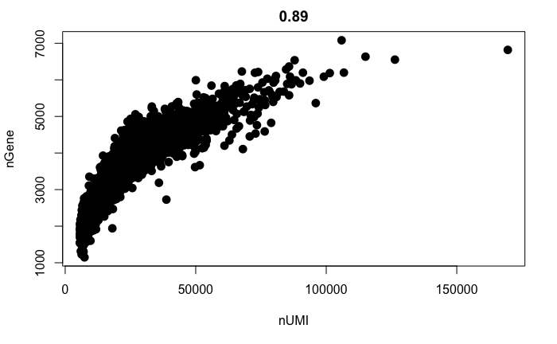

```r
GenePlot(object = tiss, gene1 = "nUMI", gene2 = "nGene", use.raw=T)
```

Filter out cells with few reads and few genes.

```r
tiss <- FilterCells(object = tiss, subset.names = c("nGene", "nUMI"),
    low.thresholds = c(500, 1000), high.thresholds = c(25000, 5000000))
```

Normalize the data, then regress out correlation with total reads

```r
tiss <- NormalizeData(object = tiss, scale.factor = 1e4)
tiss <- ScaleData(object = tiss)
```

```
[1] "Scaling data matrix"
```

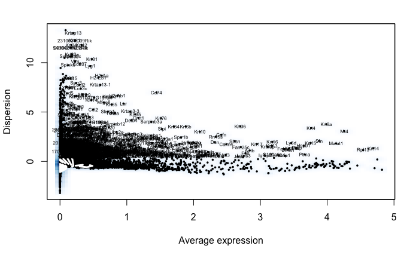

```r
tiss <- FindVariableGenes(object = tiss, do.plot = TRUE, x.high.cutoff = Inf, y.cutoff = 0.5)
```

Run Principal Component Analysis.

```r
tiss <- RunPCA(object = tiss, do.print = FALSE)
tiss <- ProjectPCA(object = tiss, do.print = FALSE)
```

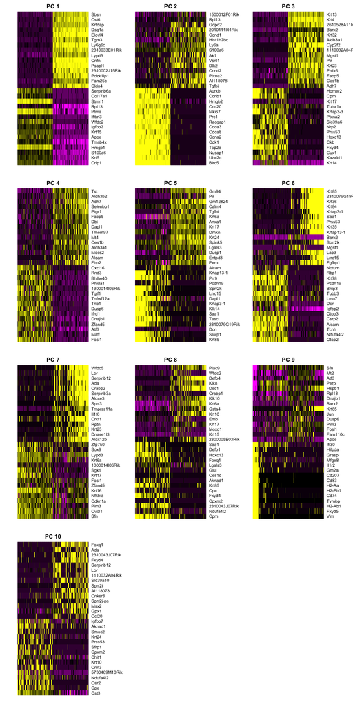

Later on (in FindClusters and TSNE) you will pick a number of principal components to use. This has the effect of keeping the major directions of variation in the data and, ideally, supressing noise. There is no correct answer to the number to use, but a decent rule of thumb is to go until the plot plateaus.

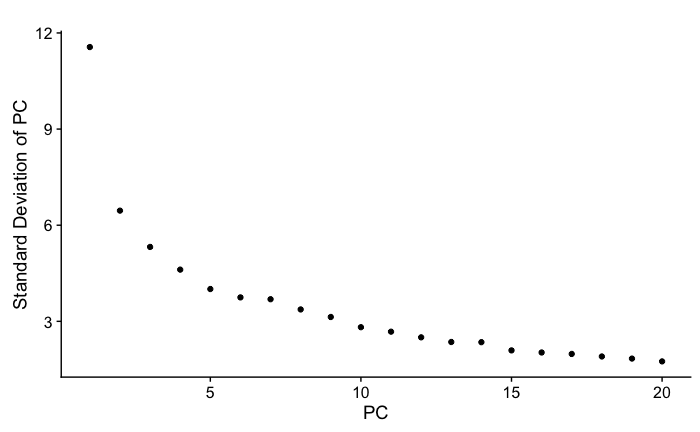

```r
PCElbowPlot(object = tiss)
```

Choose the number of principal components to use.

```r
# Set number of principal components.
n.pcs = 14
```

The clustering is performed based on a nearest neighbors graph. Cells that have similar expression will be joined together. The Louvain algorithm looks for groups of cells with high modularity–more connections within the group than between groups. The resolution parameter determines the scale…higher resolution will give more clusters, lower resolution will give fewer.

For the top-level clustering, aim to under-cluster instead of over-cluster. It will be easy to subset groups and further analyze them below.

```r
# Set resolution
res.used <- 0.4
tiss <- FindClusters(object = tiss, reduction.type = "pca", dims.use = 1:n.pcs,
    resolution = res.used, print.output = 0, save.SNN = TRUE, force.recalc = TRUE)
```

To visualize

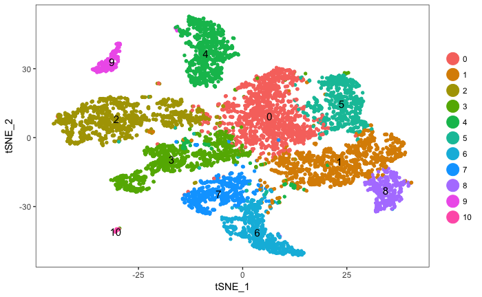

```r
# If cells are too spread out, you can raise the perplexity. If you have few cells, try a lower perplexity (but never less than 10).
tiss <- RunTSNE(object = tiss, dims.use = 1:n.pcs, seed.use = 20, perplexity=35, dim.embed = 2)
TSNEPlot(object = tiss, do.label = T, pt.size = 1.2, label.size = 4)
```

Check expression of genes of interset.

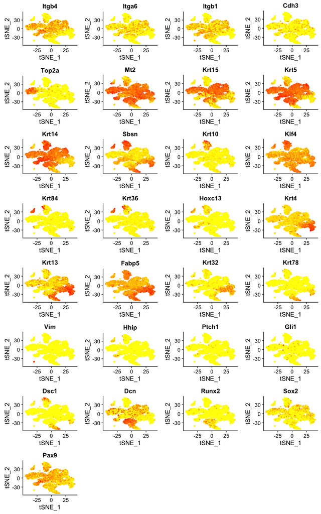

Dotplots let you see the intensity of exppression and the fraction of cells expressing for each of your genes of interest.

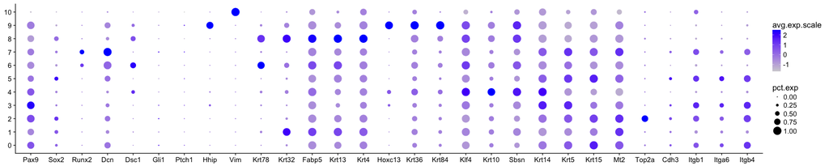

How big are the clusters?

```r
table(tiss@ident)
```

```
   0    1    2    3    4    5    6    7    8    9   10
1354 1093 1092  874  811  622  600  497  359  199   37
```

```
[1] "Finished averaging RNA for cluster 0"
[1] "Finished averaging RNA for cluster 1"
[1] "Finished averaging RNA for cluster 2"
[1] "Finished averaging RNA for cluster 3"
[1] "Finished averaging RNA for cluster 4"
[1] "Finished averaging RNA for cluster 5"
[1] "Finished averaging RNA for cluster 6"
[1] "Finished averaging RNA for cluster 7"
[1] "Finished averaging RNA for cluster 8"
[1] "Finished averaging RNA for cluster 9"
[1] "Finished averaging RNA for cluster 10"
```

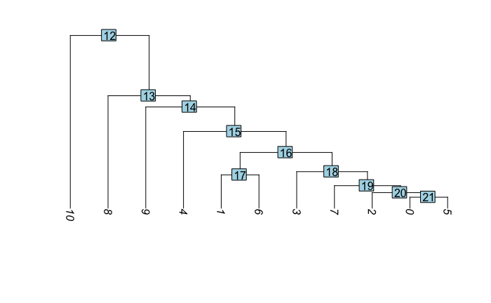

```r
tiss1=BuildClusterTree(tiss)
```

[output not shown]

Which markers identify a specific cluster?

|  | p_val | avg_logFC | pct.1 | pct.2 | p_val_adj |
| --- | --- | --- | --- | --- | --- |
| Jakmip2 | 0.000000e+00 | 0.9030659 | 0.777 | 0.072 | 0.000000e+00 |
| Notum | 0.000000e+00 | 0.7380838 | 0.740 | 0.053 | 0.000000e+00 |
| Runx2 | 0.000000e+00 | 0.3985261 | 0.544 | 0.047 | 0.000000e+00 |
| Dcn | 1.094959e-286 | 2.1503509 | 0.990 | 0.558 | 1.616816e-282 |
| Rbp1 | 3.556700e-268 | 0.9187857 | 0.742 | 0.154 | 5.251823e-264 |
| Otop3 | 6.905032e-244 | 0.6105667 | 0.736 | 0.162 | 1.019597e-239 |
| Stra6 | 4.992747e-226 | 0.2940347 | 0.323 | 0.023 | 7.372290e-222 |
| Igfbp2 | 8.363454e-202 | 1.2500888 | 1.000 | 0.946 | 1.234948e-197 |
| Otop2 | 1.963809e-195 | 0.4119160 | 0.524 | 0.086 | 2.899760e-191 |
| Eln | 7.019402e-180 | 0.2758385 | 0.370 | 0.043 | 1.036485e-175 |

[output cut: 20 more lines]

You can also compute all markers for all clusters at once. This may take some time.

[output not shown]

[output cut: 985 more lines]

[output not shown]

Display the top markers you computed above.

| p_val | avg_logFC | pct.1 | pct.2 | p_val_adj | cluster | gene |
| --- | --- | --- | --- | --- | --- | --- |
| 0.000000e+00 | 0.8336844 | 0.939 | 0.498 | 0.000000e+00 | 0 | Wfdc2 |
| 0.000000e+00 | 0.7523105 | 0.974 | 0.712 | 0.000000e+00 | 0 | Ifitm3 |
| 5.977662e-297 | 0.7907423 | 0.809 | 0.437 | 8.826616e-293 | 0 | Dusp6 |
| 4.418079e-292 | 0.6763208 | 0.891 | 0.579 | 6.523735e-288 | 0 | Tgif1 |
| 1.593008e-287 | 0.7084477 | 0.900 | 0.561 | 2.352236e-283 | 0 | Ccnd2 |
| 2.318509e-279 | 0.4483539 | 1.000 | 0.992 | 3.423510e-275 | 0 | Npm1 |
| 1.938855e-249 | 0.7650943 | 0.996 | 0.913 | 2.862914e-245 | 0 | Krt15 |
| 1.178662e-247 | 0.5515811 | 0.955 | 0.812 | 1.740412e-243 | 0 | Klf9 |
| 4.196831e-224 | 0.6258656 | 0.789 | 0.431 | 6.197040e-220 | 0 | Icam1 |
| 1.054827e-212 | 0.4961719 | 0.966 | 0.867 | 1.557557e-208 | 0 | 2410006H16Rik |

[output cut: 210 more lines]

[output not shown]

## Assigning cell type identity to clusters

At a coarse level, we can use canonical markers to match the unbiased clustering to known cell types: Cluster 0: basal cell of epidermis (CL:0002187) Cluster 1: differentiated keratinocytes (CL:0000312) Cluster 2: proliferating basal cell of epidermis (CL:0002187) Clutser 3: basal cell of epidermis (CL:0002187) Cluster 4: suprabasal differentiating keratinocytes (CL:0000312) Cluster 5: basal cell of epidermis (CL:0002187) Cluster 6: suprabasal differentiated keratinocytes (CL:0000312) Cluster 7: basal cell of epidermis (CL:0002187) Clutser 8: suprabasal differentiated keratinocytes (CL:0000312) Cluster 9: filiform differentiated keratinocytes (CL:0000312) Cluster 10: Langerhans cells (CL:0000453)

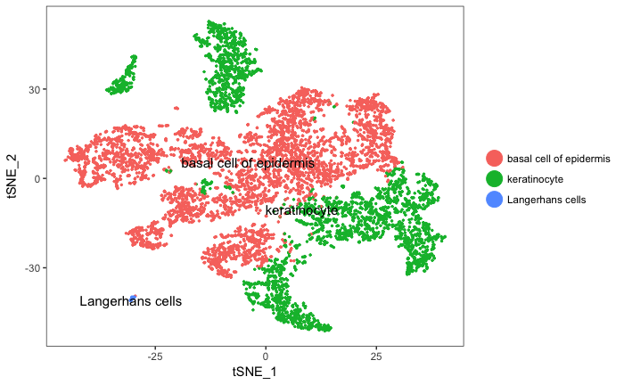

```r
# stash current cluster IDs
tiss <- StashIdent(object = tiss, save.name = "cluster.ids")
# enumerate current cluster IDs and the labels for them
cluster.ids <- c(0, 1, 2, 3, 4, 5, 6, 7, 8, 9, 10)
free_annotation <- c(
 "basal_cells",
 "differentiated",
 "proliferating",
 "basal_cells",
 "suprabasal_differentiating",
 "basal_cells",
 "suprabasal_differentiated",
 "basal_cells",
 "suprabasal_differentiated",
 "filiform_differentiated",
 "Langerhans cells"
 )
cell_ontology_class <- c(
"basal cell of epidermis",
"keratinocyte",
"basal cell of epidermis",
"basal cell of epidermis",
"keratinocyte",
"basal cell of epidermis",
"keratinocyte",
"basal cell of epidermis",
"keratinocyte",
"keratinocyte",
 "Langerhans cells"
 )
cell_ontology_id <- c(
"CL:0002187",
"CL:0000312",
"CL:0002187",
"CL:0002187",
"CL:0000312",
"CL:0002187",
"CL:0000312",
"CL:0002187",
"CL:0000312",
"CL:0000312",
"CL:0000453"
)
tiss@meta.data[,'free_annotation'] <- plyr::mapvalues(x = tiss@ident, from = cluster.ids, to = free_annotation)
tiss@meta.data[,'cell_ontology_class'] <- plyr::mapvalues(x = tiss@ident, from = cluster.ids, to = cell_ontology_class)
tiss@meta.data[,'cell_ontology_id'] <- plyr::mapvalues(x = tiss@ident, from = cluster.ids, to = cell_ontology_id)
tiss@meta.data[tiss@cell.names,'free_annotation'] <- as.character(tiss@meta.data$free_annotation)
tiss@meta.data[tiss@cell.names,'cell_ontology_class'] <- as.character(tiss@meta.data$cell_ontology_class)
tiss@meta.data[tiss@cell.names,'cell_ontology_id'] <- as.character(tiss@meta.data$cell_ontology_id)
TSNEPlot(object = tiss, do.label = TRUE, pt.size = 0.5, group.by='cell_ontology_class')
```

## Checking for batch effects

Color by metadata, like plate barcode, to check for batch effects.

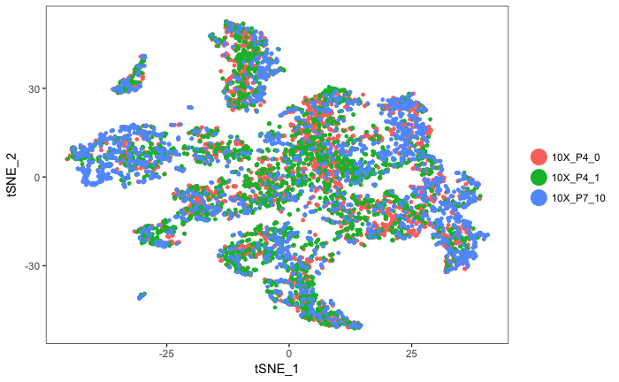

```r
TSNEPlot(object = tiss, do.return = TRUE, group.by = "channel")
```

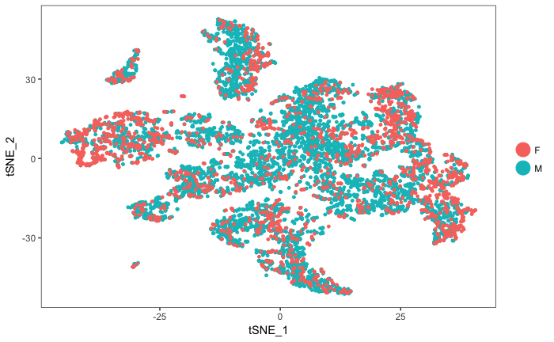

```r
TSNEPlot(object = tiss, do.return = TRUE, group.by = "mouse.sex")
```

Print a table showing the count of cells in each identity category from each plate.

```r
table(as.character(tiss@ident), as.character(tiss@meta.data$channel))
```

```
     10X_P4_0 10X_P4_1 10X_P7_10
  0       635      514       205
  1       504      290       299
  10       16        9        12
  2       320      322       450
  3       375      347       152
  4       392      270       149
  5       234      120       268
  6       229      252       119
  7       167      224       106
  8       151       65       143
  9        78       75        46
```

# Save the Robject for later

When you save the annotated tissue, please give it a name.

```r
filename = here('00_data_ingest', '04_tissue_robj_generated',
          paste0("droplet", tissue_of_interest, "_seurat_tiss.Robj"))
print(filename)
```

```
[1] "/Users/Jintonic/Documents/GitHub/tabula-muris/00_data_ingest/04_tissue_robj_generated/dropletTongue_seurat_tiss.Robj"
```

```r
save(tiss, file=filename)
```

```r
# To reload a saved object
filename = here('00_data_ingest', '04_tissue_robj_generated',
                      paste0("droplet", tissue_of_interest, "_seurat_tiss.Robj"))
 load(file=filename)
```

# Export the final metadata

So that Biohub can easily combine all your cell_ontology_classs, please export them as a simple csv.

```r
head(tiss@meta.data)
```

|  | nGene | nUMI | orig.ident | channel | tissue | subtissue | mouse.sex | percent.ercc | cell_ontology_class | subcell_ontology_class | percent.ribo | res.0.4 | cluster.ids | free_annotation | cell_ontology_id |
| --- | --- | --- | --- | --- | --- | --- | --- | --- | --- | --- | --- | --- | --- | --- | --- |
| 10X_P4_0_AAACCTGAGATTACCC | 2857 | 9848 | 10X | 10X_P4_0 | Tongue | NA | M | 0 | basal cell of epidermis | NA | 0.2480959 | 2 | 2 | proliferating | CL:0002187 |
| 10X_P4_0_AAACCTGAGTGCCAGA | 2933 | 17175 | 10X | 10X_P4_0 | Tongue | NA | M | 0 | keratinocyte | NA | 0.3957375 | 1 | 1 | differentiated | CL:0000312 |
| 10X_P4_0_AAACCTGCAAATCCGT | 3217 | 22182 | 10X | 10X_P4_0 | Tongue | NA | M | 0 | keratinocyte | NA | 0.1958433 | 4 | 4 | suprabasal_differentiating | CL:0000312 |
| 10X_P4_0_AAACCTGGTAATCGTC | 3108 | 16840 | 10X | 10X_P4_0 | Tongue | NA | M | 0 | basal cell of epidermis | NA | 0.4035869 | 0 | 0 | basal_cells | CL:0002187 |
| 10X_P4_0_AAACCTGGTCCAACTA | 3713 | 19531 | 10X | 10X_P4_0 | Tongue | NA | M | 0 | basal cell of epidermis | NA | 0.3218985 | 2 | 2 | proliferating | CL:0002187 |
| 10X_P4_0_AAACCTGGTGATAAAC | 3038 | 15894 | 10X | 10X_P4_0 | Tongue | NA | M | 0 | basal cell of epidermis | NA | 0.3925381 | 2 | 2 | proliferating | CL:0002187 |

```r
filename = here('00_data_ingest', '03_tissue_annotation_csv',
          paste0(tissue_of_interest, "_droplet_cell_ontology_class.csv"))
write.csv(FetchData(tiss, c('channel','cell_ontology_class','cell_ontology_id', 'free_annotation', 'tSNE_1', 'tSNE_2')), file=filename)
```